# Chapter 20. 모델 성능에 영향을 미치는 요인

## Overview

- The Types of the Error or Noise
  - 측정시스템: feature 측정에서의 잡음
  - 비정보성 변수: outcome과 상관없는 변수가 모델링에 쓰일 때
  - 응답변수: label의 문제

## 20.1 Type III Errors(3종오류)

- Definition
  - 잘못된 질문에 대한 모델을 만든다.

cf.

- Type I Error : False Positive
- Tyep II Error : False Negative

## 예시) 응답모델링

- 실제목표: 수익을 늘리는 것
- Basic Hypothesis
  - 단순히 만난 고객을 유효하게 만들고 모든 고객이 이 고객의 행동을 따라할 것이라고 가정
- Problems
  - 접촉한고객에 대해서만 이 고객이 구매할 확률을 예측하는 것밖에 할 수 없다.
  - 전반적인 수익을 증가시킬 수가 없다.

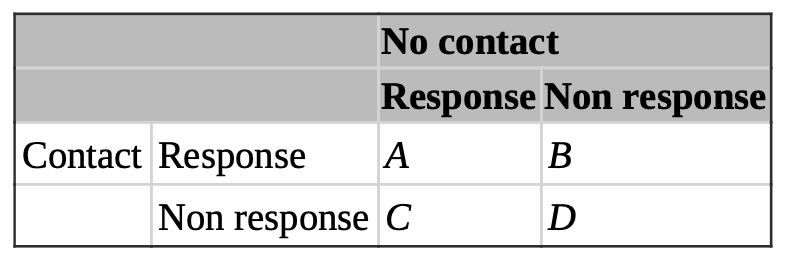

- 매출 증대를 위해 B를 정확히 예측할 수 있는 모델이 가장 유용
- 모델의 문제점
  - 항상 응답하는 고객이 있기 때문에 응답률이 과추정될 수 있다.
  - C나 D셀의 고객에게 프로모션을 보낼 경우 비용이 증가한다.
- 해결방법
  - 접촉 없이 응답한 고객의 확률을 제거하는 방식 \(Pr[response|contact] - Pr[response|no\ contact]\)
  - Paired or matched sampling(i.e. Case-control study design)

## 20.2 결과의 측정 오차

- 모델이 도달할 수 있는 최소 오차율?

e.g. Linear regression model

\(y_i = b_0 + b_1x_{i1} + b_2x_{i2} + \cdots + b_px_{ip} + e_i\)

- \(e_i \sim N(\mu, \sigma^2)\)
- 최소오차(irreducible error) = 모델 오차 + 측정상의 오차 + \(\sigma^2\)

## e.g. Solubility dataset

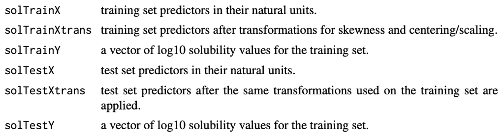

## 20.5 언제 모델의 예측값을 믿어야 할까

- 전제: 현재 존재하는 데이터를 만드는 방법과 동일한 방식으로 데이터를 계속 만들 것

즉, 새 데이터에는 동일한 특성이 포함. 모델이 만들어지는 데이터의 예측 공간의 유사한 부분을 차지할 것

새 데이터가 훈련데이터 세트와 동일한 데이터 생성 과정을 통해 만들어졌다면 이 모델은 새 데이터에 대해서도 적합한 예측을 할 것

아니라면? 외삽추정: 훈련 데이터 밖의 샘플을 모델을 사용해 예측하는 것

최삽 추정에 대한 방향을 예측 변수 공간에서 이런 빈 내부 공ㅅ간을 포함하는 것으로 확장할 필요가 있다.

## 훈련데이터와 테스트 데이터의 유사성

### scatter plot(with PCA) or 변수간의 분포 파악

- 예측변수가 별로 없는 데이터인 경우

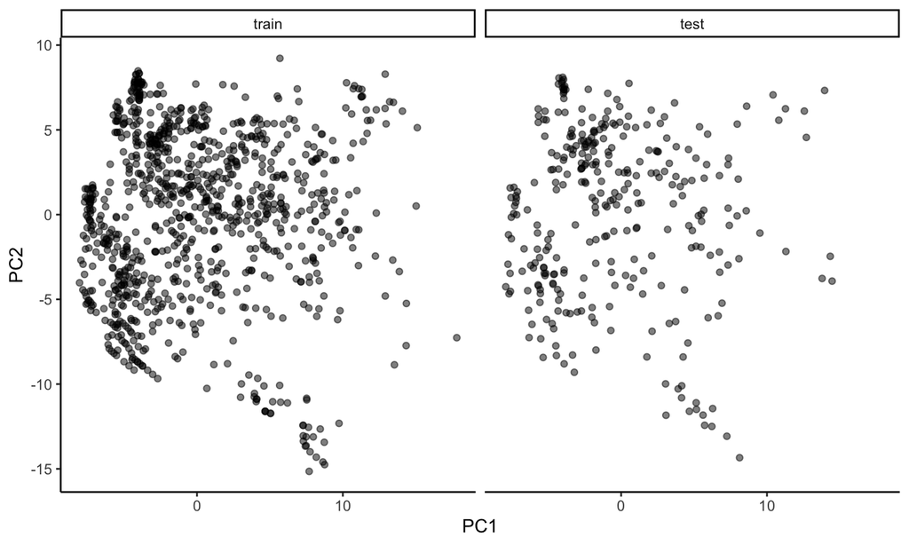

- 문제점
1. 공간 차원 증가에 따라 산점도 및 분포를 살펴보는 것은 매우 비효율적
2. 훈련 데이터 세트와 새 데이터의 변수 공간에 대해 제대로 이해하기 어려움
3. 불충분한 예측이 일어나는 변수 내 공간이 있을 수 있음

## 훈련데이터와 테스트 데이터의 유사성

### 모델 활용 도메인

예측에 사용할 새 데이터가 훈련 데이터와 충분히 유사하다면,

이 데이터 값은 모델 성능 추정값을 평균적으로 따를 것이라 가정

## 훈련데이터와 테스트 데이터의 유사성

### 수치화(헤이스티 등 2008)

1. 원 모델의 변수 중요도를 구한 후, 상위 20개의 변수를 선택한다.
2. 훈련 데이터 세트에서 이 변수들을 임의로 치환한다.
3. 원래의 훈련 세트의 상위 예측 변수와 이 변수의 임의로 치환된 버전을 행 단위로 붙인다.
4. 원룬련 세트의 행과 치환된 훈련세트의 행을 구분하는 분류 벡터를 만든다.
5. 새로 만들어진 데이터에 대해 분류 모델을 훈련한다.
6. 훈련 데이터 세트 클래스에 새 데이터가 속할 확률을 구하는 분류 모델을 만든다.

```r
knitr::include_graphics('../figure/figure_20_8.pdf')
```

[figure not shown]

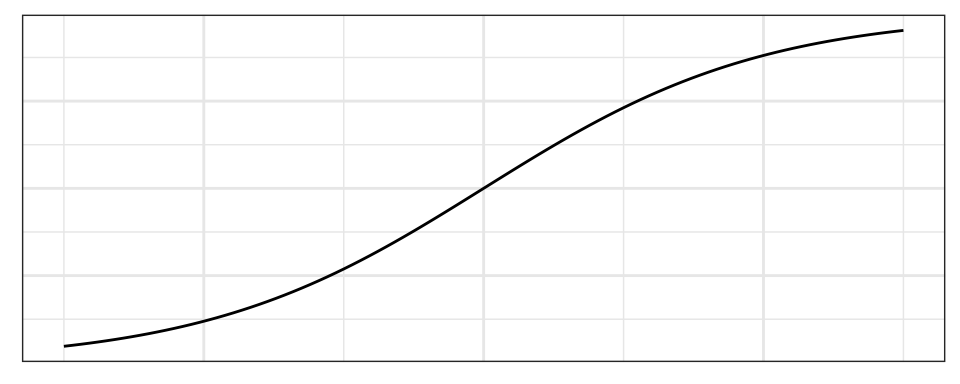